# Introduction to Regression with Multiple Variables and Logistic Regression

A Final ‘Complex’ Example for ‘Introduction to Statistical Methods’

Longhai Li

December 2019

# Packages and Functions

```r
library("plyr")
# A function for computing anova $R^2$
anova.R2 <- function (obj.lm)
{
    obj.anova <- anova (obj.lm)
    sq <- obj.anova[,"Sum Sq"]
    R2 <- sq/sum(sq)
    obj.anova[, "R2"] <- R2
    obj.anova
}
```

# 1 Read a data set

```r
temperature <- read.table("~/OneDrive - University of Saskatchewan/teaching/stat245_1909/rdemo/data/normtemp.dat.txt")
colnames(temperature) <- c("Temp", "Gender", "HR")
temperature$Gender <- mapvalues(temperature$Gender, c(2,1), c("Male", "Female"))
temperature$Gender <- as.factor(temperature$Gender)
head(temperature)
```

```
##   Temp Gender HR
## 1 96.3 Female 70
## 2 96.7 Female 71
## 3 96.9 Female 74
## 4 97.0 Female 80
## 5 97.1 Female 73
## 6 97.1 Female 75
```

# 2 Analysis of body temperatures VS gender

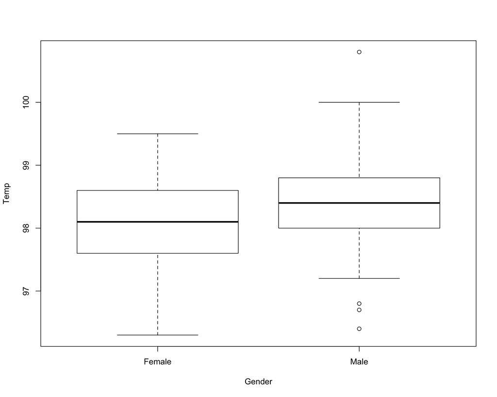

```r
boxplot(Temp~Gender, data = temperature)
```

```r
t.test(Temp~Gender,data = temperature)
```

```
##
##  Welch Two Sample t-test
##
## data:  Temp by Gender
## t = -2.2854, df = 127.51, p-value = 0.02394
## alternative hypothesis: true difference in means is not equal to 0
## 95 percent confidence interval:
##  -0.53964856 -0.03881298
## sample estimates:
## mean in group Female   mean in group Male
##             98.10462             98.39385
```

We can also use lm for comparing two means:

```r
lm_temp_gender <- lm (Temp~Gender, data = temperature)
summary (lm_temp_gender)
```

```
##
## Call:
## lm(formula = Temp ~ Gender, data = temperature)
##
## Residuals:
##      Min       1Q   Median       3Q      Max
## -1.99385 -0.47154  0.00615  0.40615  2.40615
##
## Coefficients:
##             Estimate Std. Error  t value Pr(>|t|)
## (Intercept) 98.10462    0.08949 1096.298   <2e-16 ***
## GenderMale   0.28923    0.12655    2.285   0.0239 *
## ---
## Signif. codes:  0 '***' 0.001 '**' 0.01 '*' 0.05 '.' 0.1 ' ' 1
##
## Residual standard error: 0.7215 on 128 degrees of freedom
## Multiple R-squared:  0.03921,    Adjusted R-squared:  0.0317
## F-statistic: 5.223 on 1 and 128 DF,  p-value: 0.02393
```

```r
anova.R2(lm_temp_gender)
```

```
## Analysis of Variance Table
##
## Response: Temp
##            Df Sum Sq Mean Sq F value   Pr(>F)      R2
## Gender      1  2.719 2.71877  5.2232 0.023932 0.03921
## Residuals 128 66.626 0.52052                  0.96079
```

**A note**:

The results by lm are not exactly equal to the results of t.test. In t.test, we do not assume the equality of variances in two populations, but in lm, we assume that the equality of variances in male and female groups. This is equivalent to the pooled t test, which I did not cover in this class.

**Conlusions:**

We see that the difference between male and female mean temperatures is statistical significant at the level of 0.05. That is, we have strong statistical evidence to support that the two temperature means are different between female and male. However, the difference may not be practically significant.

# 3 Regression Analysis of heart rates with gender

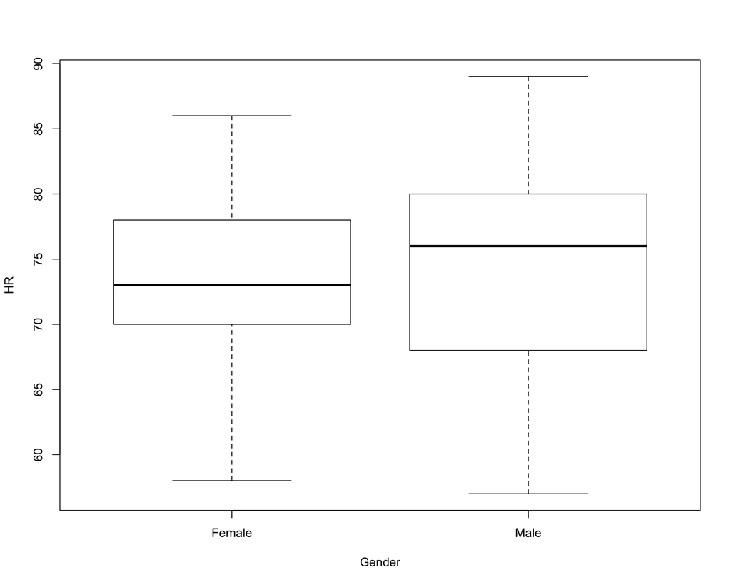

```r
boxplot(HR~Gender, data = temperature)
```

```r
t.test(HR~Gender,data = temperature)
```

```
##
##  Welch Two Sample t-test
##
## data:  HR by Gender
## t = -0.63191, df = 116.7, p-value = 0.5287
## alternative hypothesis: true difference in means is not equal to 0
## 95 percent confidence interval:
##  -3.243732  1.674501
## sample estimates:
## mean in group Female   mean in group Male
##             73.36923             74.15385
```

We can also use lm for comparing two means:

```r
summary (lm (HR~Gender, data = temperature))
```

```
##
## Call:
## lm(formula = HR ~ Gender, data = temperature)
##
## Residuals:
##      Min       1Q   Median       3Q      Max
## -17.1538  -5.1538  -0.1538   4.8462  14.8462
##
## Coefficients:
##             Estimate Std. Error t value Pr(>|t|)
## (Intercept)  73.3692     0.8780  83.565   <2e-16 ***
## GenderMale    0.7846     1.2417   0.632    0.529
## ---
## Signif. codes:  0 '***' 0.001 '**' 0.01 '*' 0.05 '.' 0.1 ' ' 1
##
## Residual standard error: 7.079 on 128 degrees of freedom
## Multiple R-squared:  0.00311,    Adjusted R-squared:  -0.004678
## F-statistic: 0.3993 on 1 and 128 DF,  p-value: 0.5286
```

# 4 Regression Analysis of body temperatures with heart rates

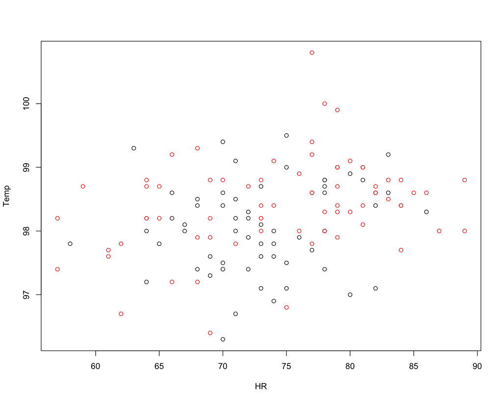

```r
plot(Temp~HR, data=temperature, col = as.numeric(temperature$Gender))
```

```r
lm_temp_hr <- lm (Temp~HR, data = temperature)

summary (lm_temp_hr)
```

```
##
## Call:
## lm(formula = Temp ~ HR, data = temperature)
##
## Residuals:
##      Min       1Q   Median       3Q      Max
## -1.85017 -0.39999  0.01033  0.43915  2.46549
##
## Coefficients:
##              Estimate Std. Error t value Pr(>|t|)
## (Intercept) 96.306754   0.657703 146.429  < 2e-16 ***
## HR           0.026335   0.008876   2.967  0.00359 **
## ---
## Signif. codes:  0 '***' 0.001 '**' 0.01 '*' 0.05 '.' 0.1 ' ' 1
##
## Residual standard error: 0.712 on 128 degrees of freedom
## Multiple R-squared:  0.06434,    Adjusted R-squared:  0.05703
## F-statistic: 8.802 on 1 and 128 DF,  p-value: 0.003591
```

```r
anova(lm_temp_hr)
```

```
## Analysis of Variance Table
##
## Response: Temp
##            Df Sum Sq Mean Sq F value   Pr(>F)
## HR          1  4.462  4.4618  8.8021 0.003591 **
## Residuals 128 64.883  0.5069
## ---
## Signif. codes:  0 '***' 0.001 '**' 0.01 '*' 0.05 '.' 0.1 ' ' 1
```

We see that the p-value of HR is significant. A practical significance measure is the $R^2$:

```r
anova.R2(lm_temp_hr)
```

```
## Analysis of Variance Table
##
## Response: Temp
##            Df Sum Sq Mean Sq F value    Pr(>F)      R2
## HR          1  4.462  4.4618  8.8021 0.0035915 0.06434
## Residuals 128 64.883  0.5069                   0.93566
```

We see that the variation of temperature explained by HR is very small.

# 5 Regression Analysis of body temperatures with heart rates and gender

We may be wondering whether the temperature still diff in female and male after the effects of HR is considered. We will fit such a multiple regression model:

```r
lm_temp_hr_gender <- lm (Temp~HR + Gender, data = temperature)
# What model is fitted?
model.matrix(lm_temp_hr_gender)[c(1:3,1:3+70),]
```

```
##    (Intercept) HR GenderMale
## 1            1 70          0
## 2            1 71          0
## 3            1 74          0
## 71           1 57          1
## 72           1 61          1
## 73           1 84          1
```

```r
# the coefficients:
betas <- lm_temp_hr_gender$coefficients; betas
```

```
## (Intercept)          HR  GenderMale
## 96.25081404  0.02526674  0.26940610
```

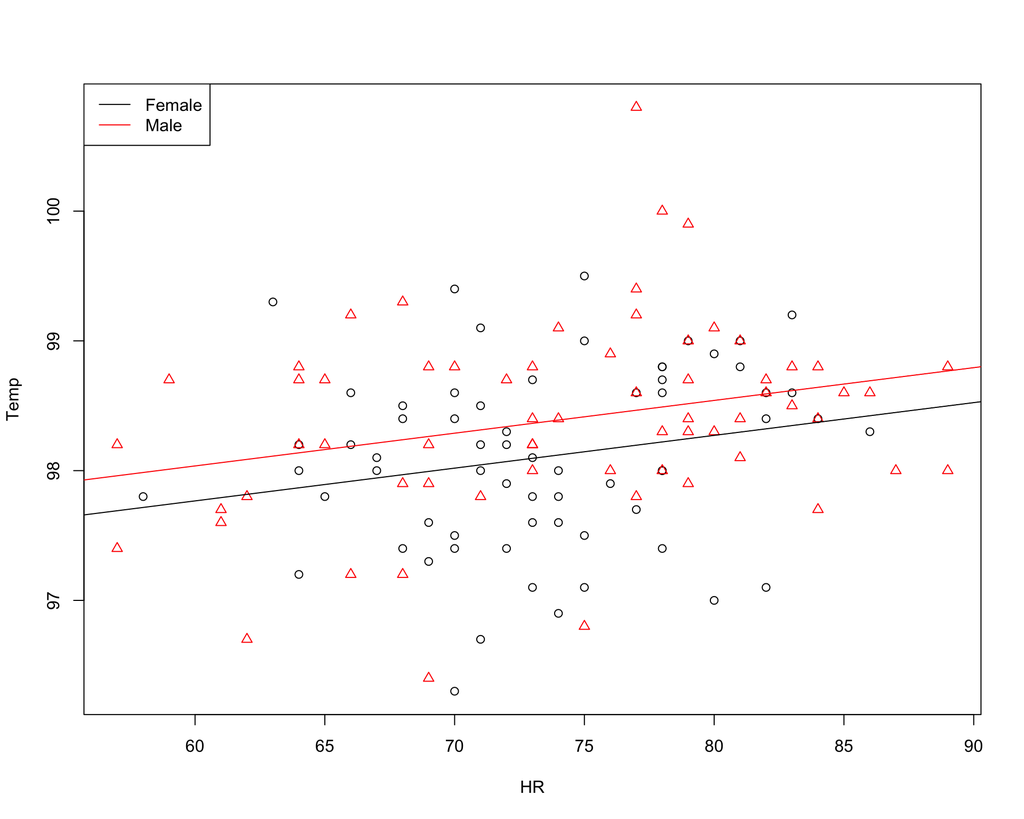

```r
# visualize the fitting results:
gender.n <- as.numeric(temperature$Gender)
plot(Temp~HR, data=temperature, col = gender.n, pch = gender.n )
abline(a= betas[1], b = betas["HR"], col=1)
abline(a= betas[1]+betas["GenderMale"], b = betas["HR"], col=2)
legend("topleft", col=1:2,lty=c(1,1), legend = c("Female", "Male"))
```

```r
summary (lm_temp_hr_gender)
```

```
##
## Call:
## lm(formula = Temp ~ HR + Gender, data = temperature)
##
## Residuals:
##      Min       1Q   Median       3Q      Max
## -1.86363 -0.45624  0.01841  0.47366  2.33424
##
## Coefficients:
##              Estimate Std. Error t value Pr(>|t|)
## (Intercept) 96.250814   0.648717 148.371  < 2e-16 ***
## HR           0.025267   0.008762   2.884  0.00462 **
## GenderMale   0.269406   0.123277   2.185  0.03070 *
## ---
## Signif. codes:  0 '***' 0.001 '**' 0.01 '*' 0.05 '.' 0.1 ' ' 1
##
## Residual standard error: 0.7017 on 127 degrees of freedom
## Multiple R-squared:  0.09825,    Adjusted R-squared:  0.08405
## F-statistic: 6.919 on 2 and 127 DF,  p-value: 0.001406
```

```r
anova.R2(lm_temp_hr_gender)
```

```
## Analysis of Variance Table
##
## Response: Temp
##            Df Sum Sq Mean Sq F value    Pr(>F)      R2
## HR          1  4.462  4.4618  9.0617 0.0031494 0.06434
## Gender      1  2.352  2.3515  4.7758 0.0306964 0.03391
## Residuals 127 62.532  0.4924                   0.90175
```

**Conclusions**

After we remove the influence of HR, the gender is still statistically significant at the level of 0.05, but the practical significance measured with $R^2$ may be minor.

# 6 A Webpage about Body Temperature Difference

https://www.fatherly.com/health-science/why-women-are-colder-than-men/

# 7 Logistic Regression for Gender with body temperatures

Fit a logistic model:

```r
model_gender_temp <- glm (Gender~Temp, family=binomial(link="logit"),data=temperature)
```

Looking at the fitted model with data

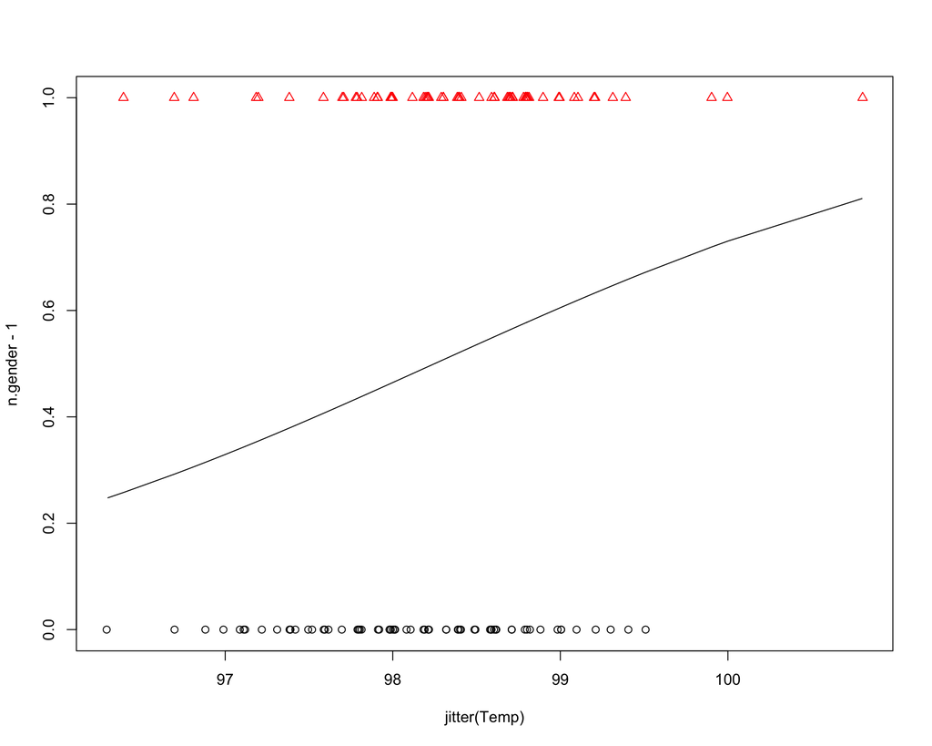

```r
prob_pred <- predict(model_gender_temp, type = "response")
with(temperature,
{
  n.gender <- as.numeric(Gender)
  o.temp <- order(Temp)
  plot(n.gender-1~jitter(Temp), col=n.gender,pch=n.gender)
  lines(prob_pred[o.temp]~Temp[o.temp])
}
)
```

Looking at the predictions

```r
predicted.gender <- mapvalues(prob_pred > 0.5, c(1,0), c("Male", "Female"))
pred.error <- (predicted.gender != temperature$Gender)*1
pred.table <- cbind(temperature,
                          data.frame(predicted.gender,
                                     "Prob of Male"=prob_pred,
                                     pred.error)
)
pred.table
```

```
##      Temp Gender HR predicted.gender Prob.of.Male pred.error
## 1    96.3 Female 70           Female    0.2477981          0
## 2    96.7 Female 71           Female    0.2926458          0
## 3    96.9 Female 74           Female    0.3167696          0
## 4    97.0 Female 80           Female    0.3292229          0
## 5    97.1 Female 73           Female    0.3419207          0
## 6    97.1 Female 75           Female    0.3419207          0
## 7    97.1 Female 82           Female    0.3419207          0
## 8    97.2 Female 64           Female    0.3548492          0
## 9    97.3 Female 69           Female    0.3679932          0
## 10   97.4 Female 70           Female    0.3813363          0
## 11   97.4 Female 68           Female    0.3813363          0
## 12   97.4 Female 72           Female    0.3813363          0
## 13   97.4 Female 78           Female    0.3813363          0
## 14   97.5 Female 70           Female    0.3948609          0
```

[output cut: 116 more lines]

Error rate in prediction

```r
er <- mean(pred.table$pred.error); er
```

```
## [1] 0.4230769
```

```r
er0<-min(table(temperature$Gender)/nrow(temperature));er0
```

```
## [1] 0.5
```

```r
R2.err <- (er0-er)/er0; R2.err
```

```
## [1] 0.1538462
```

# 8 Logistic Regression for Gender with modified body temperatures

Create a fake dataset by adding 1F to the temperatures of males

```r
temperature2 <- temperature
indicator.male <- temperature$Gender=="Male"
temperature2$Temp[indicator.male] <- temperature$Temp[indicator.male] + 1
```

Fit a logistic model:

```r
model_gender_temp <- glm (Gender~Temp, family=binomial(link="logit"),data=temperature2)
```

Looking at the fitted model

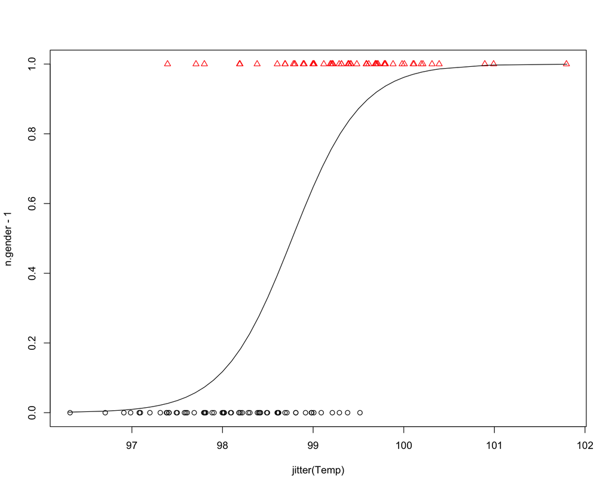

```r
prob_pred <- predict(model_gender_temp, type = "response")
with(temperature2,
{
  n.gender <- as.numeric(Gender)
  o.temp <- order(Temp)
  plot(n.gender-1~jitter(Temp), col=n.gender,pch=n.gender)
  lines(prob_pred[o.temp]~Temp[o.temp])
}
)
```

Looking at the predictions

```r
predicted.gender <- mapvalues(prob_pred > 0.5, c(1,0), c("Male", "Female"))
pred.error <- (predicted.gender != temperature$Gender)*1
pred.table <- cbind(temperature,
                          data.frame(predicted.gender,
                                     "Prob of Male"=prob_pred,
                                     pred.error)
)
pred.table
```

```
##      Temp Gender HR predicted.gender Prob.of.Male pred.error
## 1    96.3 Female 70           Female  0.001548955          0
## 2    96.7 Female 71           Female  0.004405894          0
## 3    96.9 Female 74           Female  0.007418867          0
## 4    97.0 Female 80           Female  0.009620182          0
## 5    97.1 Female 73           Female  0.012466464          0
## 6    97.1 Female 75           Female  0.012466464          0
## 7    97.1 Female 82           Female  0.012466464          0
## 8    97.2 Female 64           Female  0.016141138          0
## 9    97.3 Female 69           Female  0.020876079          0
## 10   97.4 Female 70           Female  0.026961933          0
## 11   97.4 Female 68           Female  0.026961933          0
## 12   97.4 Female 72           Female  0.026961933          0
## 13   97.4 Female 78           Female  0.026961933          0
## 14   97.5 Female 70           Female  0.034758970          0
```

[output cut: 116 more lines]

Error rate in prediction

```r
er <- mean(pred.table$pred.error); er
```

```
## [1] 0.1615385
```

```r
er0<-min(table(temperature$Gender)/nrow(temperature));er0
```

```
## [1] 0.5
```

```r
R2.err <- (er0-er)/er0; R2.err
```

```
## [1] 0.6769231
```